# Final Project

Tiejun Zhang

### Normal

The Normal distribution is used to model continuous data that have a symmetric distribution.

The mean-variance relationship: $V (\mu) = 1$

Dispersion: The dispersion $??$ is unknow and needs to be estimated. There are four types of estimators: MLE estimator, Modified profile log-likelihood estimator, Mean deviance estimator, Pearson estimator. MLE estimator is biased, unless $p'/n$ is very small, the modified profile estimator is difficult to compute. In practice, the Pearson estimator tends to be more variable (less precise) but less biased than the mean deviance estimator. For normal GLMs, the latter three estimators make little difference.The mean deviance and Pearson estimators are very convenient.The mean deviance estimator should behave well when the saddlepoint approximation holds; that is, for normal or inverse Gaussian glms or when $??$ is relatively small.

Link function: $\eta = \mu$

Inference: Walds test, Likelihood ratio and score test with selected estimator.All tests are based on large-sample asymptotic results, which apply when n is reasonably large. Walds test is the most commonly used. Confidence intervals for $\hat{\mu}$ are found by first computing confidence intervals for $\hat{\eta}$, and then applying the inverse link function (that is, ?? = g???1(??)) to the lower and upper limit of the interval found for $\hat{\eta}$. Likelihood ratio deals with nested models. The score test evaluates the usefulness of predictors.

The saddlepoint approximation is exact for the normal distribution.

Diagnostic Analysis: The three main types of residuals are raw residuals, standardized residuals, and Studentized residuals. The standardized and Studentized residuals have approximately constant variance of one, and are preferred in residual plots. Check for independence of the responses when possible. Check for linearity between the responses and all covariates Residuals against the fitted values Q-Q plot Cook’s distance plot Influential observations

Solutions If the responses are not independent, use other methods. If the variance of the response is not approximately constant, transform the response as necessary. if the relationship is not linear, transform the covariates using simple transformations (Sect. 3.10), polynomials in the covariates (Sect. 3.11), or regression splines (Sect. 3.12).

#### Data discription

The data set is available as the *crawl* data in the GLMsData library.

The data come from a study which hypothesized that babies would take longer to learn to crawl in colder months because the extra clothing restricts their movement. From 1988 to 1991, researchers recorded the babies’ first crawling age and the average monthly temperature 6 months after birth (when ``infants presumably enter the window of locomotor readiness’’). The parents reported the birth month and age when their baby first crept or crawled a distance of four feet in one minute. Data were collected at the University of Denver Infant Study Center on 208 boys and 206 girls, and summarized by the birth month.

#### Variables

BirthMonth: the baby’s birth month

Age: the mean age (in completed weeks) at which the babies born this month started to crawl

SD: the standard deviation (in completed weeks) of the crawling ages for babies born this month

SampleSize: the number of babies in the study born in the given month

Temp: the monthly average temperature (in degrees F) six months after the birth month

#### Research question

What is the effect of temperature (six months after birth) on the age when babies start to crawl?

For every 1 (degree F) increase in temperature, the mean age for babies starting to crawl woiuld be 0.08 weeks (about half day) earlier.

#### Analysis

1. Prepare the data and take a look at the data structure

```r
library(GLMsData)
data(crawl)
str(crawl)
```

[output not shown]

```r
head(crawl)
```

|  | BirthMonth | Age | SD | SampleSize | Temp |
| --- | --- | --- | --- | --- | --- |
| 1 | January | 29.84 | 7.08 | 32 | 66 |
| 2 | February | 30.52 | 6.96 | 36 | 73 |
| 3 | March | 29.70 | 8.33 | 23 | 72 |
| 4 | April | 31.84 | 6.21 | 26 | 63 |
| 5 | May | 28.58 | 8.07 | 27 | 52 |
| 6 | June | 31.44 | 8.10 | 29 | 39 |

2. Explore the relationship between the response and predictor.

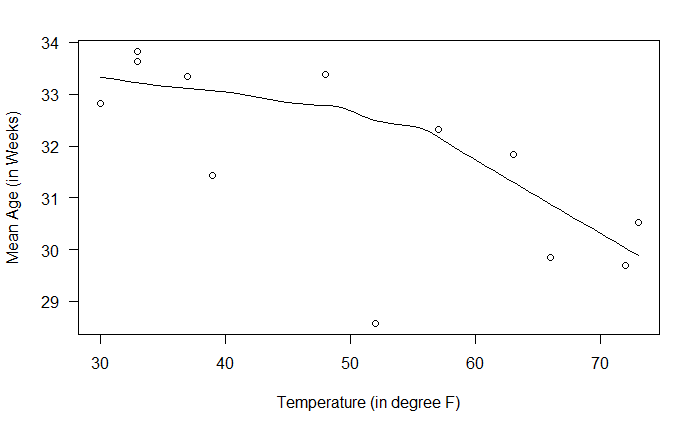

```r
scatter.smooth(crawl$Temp,
               crawl$Age,las = 1,
               xlab = "Temperature (in degree F)",
               ylab = "Mean Age (in Weeks)")
```

3. Let us model age with temperature.

```r
crawl.model <- glm(Age ~ Temp,
                  data = crawl,
                  weights = SampleSize,
                  family = gaussian)
printCoefmat(coef(summary(crawl.model)))
```

[output not shown]

The model test results indicate that temperature indeed exert an infulence on the mean age at which the babies started to crawl. For every 1 (degree F) increase in temperature, the mean age woiuld decrease by 0.08 weeks.

4. Dianostic Analysis

The residuals against the fitted values, the standardized residuals was used here.

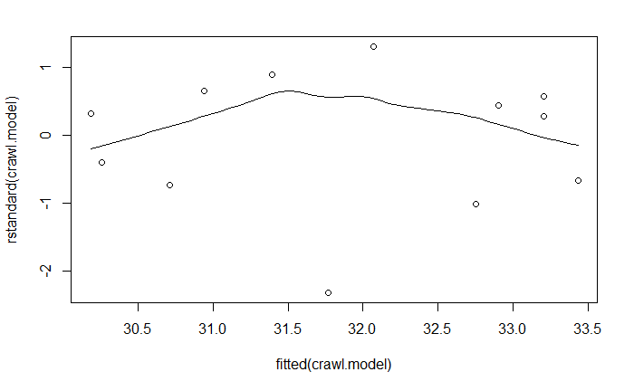

```r
scatter.smooth(rstandard(crawl.model) ~ fitted(crawl.model))
```

Q-Q Plot

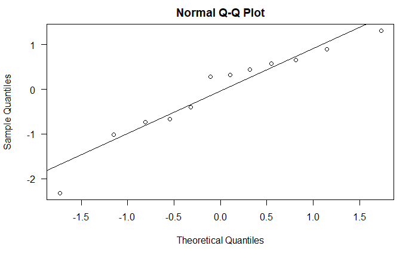

```r
qqnorm( rstandard( crawl.model ), las=1 )
qqline( rstandard( crawl.model ) )
```

Cook’s distance

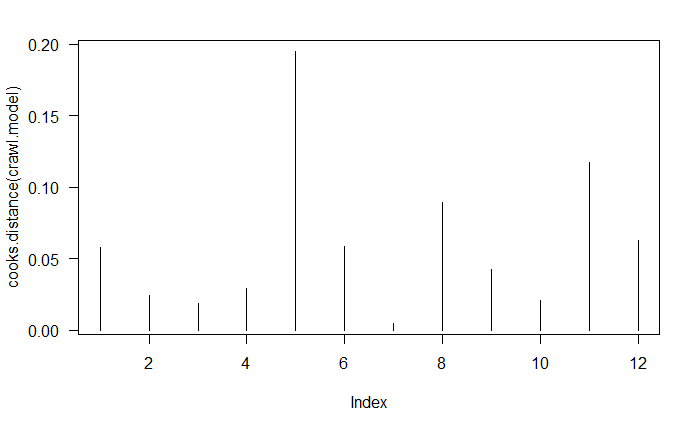

```r
plot( cooks.distance(crawl.model), type="h", las=1)
```

The plots look acceptable, but there is a lack of linearity.

Influential observations

```r
im <- influence.measures(crawl.model)
colSums(im$is.inf)
```

```
  dfb.1_ dfb.Temp    dffit    cov.r   cook.d      hat
       0        0        0        2        0        0
```

The influence diagnostics reveal that two observations are influential according to covariance ratio, but none are influential according to Cook’s distance.

#### Additional exercise

We learned that the Wald test, the likelihood ratio test, and the score test all provide the same result for the normal EDM. Verify that this is the case for these data and your model.

Wald test

```r
phi.meandev <- deviance(crawl.model) / df.residual(crawl.model)
phi.pearson <- summary(crawl.model)$dispersion
# Both the mean deviance and Pearson estimators are similar.
# The mean deviance estimator is used.
printCoefmat(coef(summary(crawl.model, dispersion = phi.pearson)))
```

[output not shown]

Likelihood ratio test

```r
anova(crawl.model, test = "F", dispersion = phi.meandev)
```

```
using F test with a fixed dispersion is inappropriate
```

[output not shown]

Score test

```r
library(statmod)
m0 <- glm(Age ~ 1,
                data = crawl,
                weights = SampleSize,
                family = gaussian)
t.Ht <- glm.scoretest(m0, crawl$Temp)
p.Ht <- 2 * pt(-abs(t.Ht), df = df.residual(m0))
tab <- data.frame(Score.stat = t.Ht, P.value = p.Ht)
print(tab, digits = 3)
```

| Score.stat | P.value |
| --- | --- |
| -2.314549 | 0.04096927 |

All tests suggest that the predictor is effective (p < 0.05), but the score test is much more conservative (p = 0.041) than the Wald and Likelihood tests (p = 0.002).

### Binomial

The binomial GLM is used to model proportions.

The mean-variance relationship: $V (\mu) = \mu(1-\mu)$

Dispersion: The dispersion $??$ is known to be $1/m$, no estimation is necessary.However, there may be overdispersion issue.

Link function: 1. logit link function (canonical and default); 2. probit link function; 3. complementary log-log link function.The logit and probit link functions are very similar, and both are symmetric about $\mu$ = 0.5, whereas the complementary log-log link function is not.

The ed50 is the value of the covariates when the expected proportion is $\mu$ = 0.5.

Inference: Wald test doesn’t work well with binomial GLMs. The score or likelihood ratio tests must be used.

The saddlepoint aprroximation is adequate for binomial distribution when my ??? 3 and m(1 ??? y) ??? 3.

Overdispersion: compare residual deviance and the Pearson goodness-of-fit statistic to the residual degrees of freedom. Substantial differences suggest overdispersion. Overdispersion may arises from: 1.the $m_i$ cases, of which observation $y_i$ is a proportion, are not independent. (solution: use hierachical models); 2.the Bernoulli cases, that $m_i$ make up observation, are positively correlated. (solution: Quasi-binomial models)

No Goodness-of-Fit for Binary Responses

Diagnostic analysis of the model: quantile residuals against the fitted values Q-Q plot Cook’s distance influential observations.

#### Data

The data set is available as the *belection* data in the GLMsData library.

The data give the number of male and females candidates in the British general election held April 9, 1992.

#### Variables

Region: the region in Britain

Party: the political party

Females: the number of female candidates

Males: the number of male candidates

#### Research question

Assuming that the current political parties and views of British voters are similar now as they were in 1992 (which may not be a reasonable assumption), what factors can best be used to predict female participation as a candidate in British elections?

The factor Party is an effective predictor. Compared to the conservative party, the odds of a female being nominated as a candidate in the Green Party is 3.16 greater. The odds in the Labour Party and Other Party is 2.5 greater and in the Liberty Demoncratic Party is 2.78 grater than the consevative party.

#### Analysis

1.Prepare the data

```r
data(belection)
str(belection)
```

```
'data.frame':   55 obs. of  4 variables: $ Region : Factor w/ 10 levels "EastAnglia","EastMidlands",..: 6 7 3 1 2 8 5 9 10 4 ...
 $ Party  : Factor w/ 5 levels "Cons","Green",..: 1 1 1 1 1 1 1 1 1 1 ... $ Females: int  8 3 8 1 3 2 9 8 3 8 ...
 $ Males  : int  101 45 76 19 39 36 63 50 51 65 ...
```

```r
summary(belection)
```

```
           Region      Party       Females           Males
 NorthWest    :10   Cons  :11   Min.   : 0.000   Min.   :  6.00
 EastAnglia   : 5   Green :11   1st Qu.: 4.000   1st Qu.: 22.00
 EastMidlands : 5   Labour:11   Median : 8.000   Median : 37.00
 GreaterLondon: 5   LibDem:11   Mean   : 9.345   Mean   : 42.16
 Scotland     : 5   Other :11   3rd Qu.:12.500   3rd Qu.: 59.00
 SouthEast    : 5               Max.   :28.000   Max.   :101.00
 (Other)      :20
```

Let us create a variable Total by summing all male and female candidates.

```r
belection$Total <- belection$Males + belection$Females
```

2. Explore the relationship between the response and predictors.

Here is a visual display to help us determine if region make a difference on the proportion of female candidates.

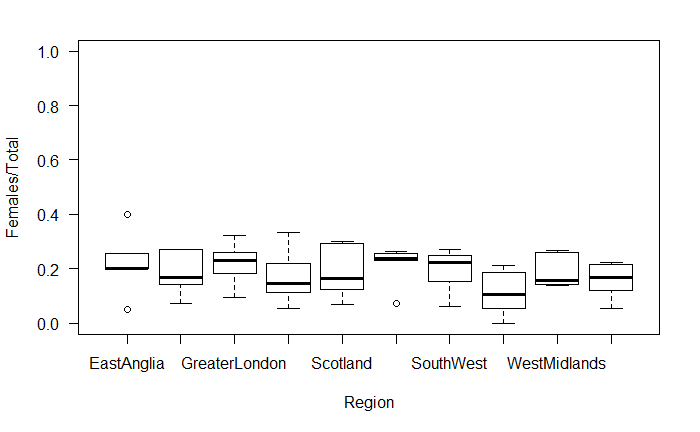

```r
plot(Females / Total ~ Region,
     data = belection,
     las = 1,
     ylim = c(0,1))
```

Overall, there are much more male candiates than female candiates in every region. Several regions have more than 20% female candidates while most regions are below 20%.

Here is a visual display to help us determine if Party makes a difference.

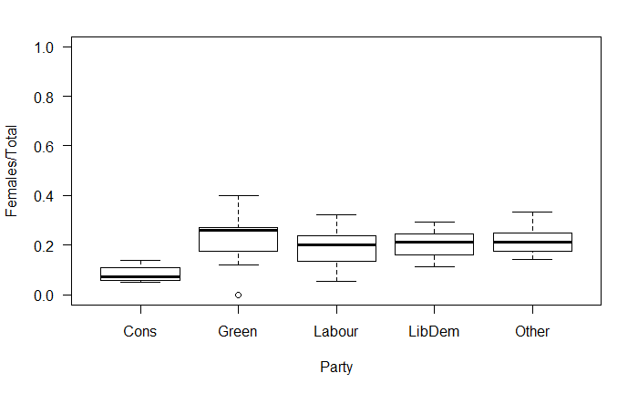

```r
plot(Females / Total ~ Party,
     data = belection,
     las = 1,
     ylim = c(0,1))
```

The Conservative Party on average has 10%, the lowest proportion, female candidates and the Green Party has the highest 30% female candidates. The other three parties have 20% female candiates.

3. Fit model.

Let us start with the interaction model

```r
female.model <- glm(Females / Total ~ Party * Region,
                    data = belection,
                    family = binomial,
                    weights = Total)
anova(female.model, test = "Chisq")
```

[output not shown]

The likelihood test suggests that only Party makes a difference in the proportion of female candidates.

```r
female.model2 <- glm(Females / Total ~ Party,
                    data = belection,
                    family = binomial,
                    weights = Total)
printCoefmat(coef(summary(female.model2)))
```

[output not shown]

Party membership does make a difference!

Let us see how R dummy-coded the levels of Party

```r
contrasts(belection$Party)
```

```
       Green Labour LibDem Other
Cons       0      0      0     0
Green      1      0      0     0
Labour     0      1      0     0
LibDem     0      0      1     0
Other      0      0      0     1
```

Now let’s look at the effect sizes.

```r
exp(coef(female.model2))
```

```
(Intercept)  PartyGreen PartyLabour PartyLibDem  PartyOther
 0.09878683  3.16337719  2.51077497  2.77560838  2.50289184
```

Conservative party was set as the reference level by R, so the odds of a female being nominated as a candidate in the Green Party is 3.16 greater than in the conservative Party. The odds in the Labour Party and Other Party is 2.5 greater and in the Liberty Demoncratic Party is 2.78 grater than in the consevative party.

4.Diagnostic Analysis

Overdispersion

```r
c(Df = df.residual(female.model2),
Resid.Dev = deviance(female.model2),
Pearson.X2 = sum( resid(female.model2, type="pearson")^2 ))
```

```
        Df  Resid.Dev Pearson.X2
  50.00000   60.82430   56.02685
```

There is not too much difference between the three statistics.

Quantile residual vs fitted values.

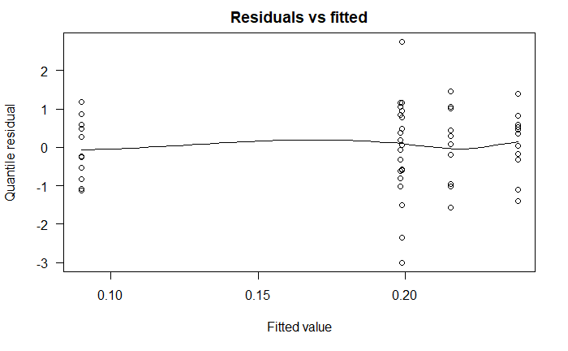

```r
qres <- qresid(female.model2)
scatter.smooth(qres ~ fitted(female.model2),
               las = 1,
               main = "Residuals vs fitted",
               xlab = "Fitted value",
               ylab = "Quantile residual")
```

Q-Q Plot

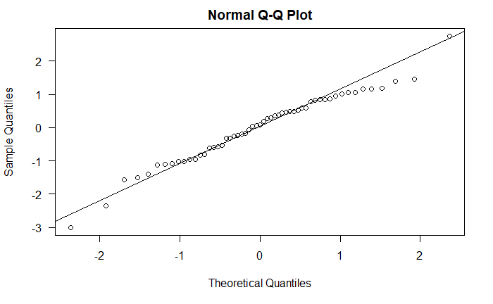

```r
qqnorm(qres, las=1 )
qqline(qres)
```

Cook’s distance

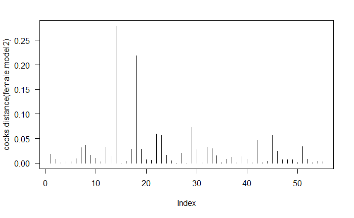

```r
plot( cooks.distance(female.model2), type="h", las=1)
```

The plots are pretty good.

Influential observations

```r
im <- influence.measures(female.model2)
colSums(im$is.inf)
```

[output not shown]

The influence diagnostics reveal that two observations are influential according to DFFITS, but none are influential according to Cook’s distance.

#### Additional questions

1. How do you check for overdispersion when modeling proportions?

To look for overdispersion we compare residual deviance and the Pearson goodness-of-fit statistic to the residual degrees of freedom. Substantial differences suggest overdispersion.

2. Is there evidence of overdispersion in your chosen model?

*No evidence of overdispersion. There are not much difference between the residual deviance or the Pearson goodness-of-fit statistic and the residual degrees of freedom.*

```r
c(Df = df.residual(female.model2),
  Resid.dev = deviance(female.model2),
  Pearson.X2 = sum(resid(female.model2, type = "pearson")^2))
```

```
        Df  Resid.dev Pearson.X2
  50.00000   60.82430   56.02685
```

3. Whether or not there is evidence of overdispersion in your model, how would you change your analysis if you **did** detect overdispersion?

Overdispersion can arise from two major causes. The probabilitiesf $\mu_i$ are not constant between observations. Alternatively the $m_i$ cases, of which observation $y_i$ is a proportion, are not independent., we can address this type of overdispersion by a hierachical model. If overdispersion arises when $m_i$ Bernoulli cases, that make up observations $y_i$, are positively correlated, we could use quasi-binomial models.

### Poisson

The Poisson distribution is used to model count data. Poisson glms can be used to model rates (such as counts of cancer cases per unit of population) by using a suitable offset in the linear predictor.

The mean-variance relationship: $V (\mu) = \mu)$

Dispersion: The dispersion $??$ is known to be 1, no estimation is necessary.However, there may be overdispersion issue.

log-linear model: all explanatory variables are factors, the data can be summarized as a contingency table. Poisson regression model: If any of the explanatory variables are quantitative.

Structure zeros: Contingency tables may contain cells with zero counts, cells containing structural zeros must be removed from the analysis.

Inference: Wald test, score or likelihood ratio tests can be used.

The saddlepoint aprroximation is adequate for Poisson distribution when y ??? 3.

Overdispersion: occurs when the variation in the responses is greater than expected under the Poisson model. Possible causes are that the model is misspecified (in which case the model should be amended), the means are not constant, or the responses are not independent. (solutions: Negative binomial GLMS and Qusi-poisson models)

Diagnostic analysis: Overdispersion quantile residuals against the fitted values Q-Q plot Cook’s Distance plot Influential observation

The data set is available as the *Sociology Survey Data* in an RData file provided via Blackboard.

Graduate students in sociology and other disciplines were randomly selected from the graduate student population at one university. They were asked, “What is the most important way to reduce crime?”

#### Variables

Response: (1) increase penalties, (2) increase police force, (3) increase social services, (4) none of these

Major: (1) sociology, (2) other

Gender: (1) male, (2) female

#### Research questions

How do sociology graduate students differ from other graduate students in their perceptions about dealing with crime? Do these perceptions differ based on gender?

The graudate students from other majors have much lower odds to select $social service$ and $none$ than those who from sociology. The odds ratio for selecting social service is 0.06 and the odds ratio for none is 0.09. Gender does not affect the perceptions very much.

#### Analysis

1. Prepare the data.

```r
load("Sociology Survey Data.RData")
str(soc_survey)
```

[output not shown]

```r
head(soc_survey)
```

|  | response | major | gender |
| --- | --- | --- | --- |
| 1 | 4 | 2 | 1 |
| 2 | 4 | 2 | 2 |
| 3 | 4 | 2 | 1 |
| 4 | 3 | 1 | 1 |
| 5 | 4 | 1 | 2 |
| 6 | 4 | 2 | 2 |

```r
summary(soc_survey)
```

```
    response         major           gender
 Min.   :1.000   Min.   :1.000   Min.   :1.000
 1st Qu.:2.000   1st Qu.:1.000   1st Qu.:1.000
 Median :3.000   Median :2.000   Median :1.000
 Mean   :2.938   Mean   :1.506   Mean   :1.488
 3rd Qu.:4.000   3rd Qu.:2.000   3rd Qu.:2.000
 Max.   :4.000   Max.   :2.000   Max.   :2.000
```

Recode variables as factors.

```r
soc_survey$response <- factor(soc_survey$response,
                              levels = c(1, 2, 3, 4),
                              labels = c("penalty", "police force", "social services", "none"))
soc_survey$major <- factor(soc_survey$major,
                           labels = c("Sociology", "Other"))
soc_survey$gender <- factor(soc_survey$gender,
                            labels = c("male", "female"))
```

Let us calculate counts for each condition cell.

```r
ss.counts <- table(soc_survey)
ss.counts <- data.frame(ss.counts)
names(ss.counts) <- c("Response", "Major", "Gender", "Counts")
ss.counts
```

| Response | Major | Gender | Counts |
| --- | --- | --- | --- |
| penalty | Sociology | male | 1 |
| police force | Sociology | male | 6 |
| social services | Sociology | male | 16 |
| none | Sociology | male | 20 |
| penalty | Other | male | 5 |
| police force | Other | male | 16 |
| social services | Other | male | 8 |
| none | Other | male | 10 |
| penalty | Sociology | female | 0 |
| police force | Sociology | female | 2 |

[output cut: 6 more lines]

Remove the cell that contains structure zero

```r
ss.counts1 <- subset(ss.counts, ss.counts$Counts != 0)
ss.counts1
```

|  | Response | Major | Gender | Counts |
| --- | --- | --- | --- | --- |
| 1 | penalty | Sociology | male | 1 |
| 2 | police force | Sociology | male | 6 |
| 3 | social services | Sociology | male | 16 |
| 4 | none | Sociology | male | 20 |
| 5 | penalty | Other | male | 5 |
| 6 | police force | Other | male | 16 |
| 7 | social services | Other | male | 8 |
| 8 | none | Other | male | 10 |
| 10 | police force | Sociology | female | 2 |
| 11 | social services | Sociology | female | 19 |

[output cut: 5 more lines]

Here it is as a contingency table.

```r
gm.table <- xtabs(Counts ~ Response+ Major  + Gender, data = ss.counts1)
gm.table
```

[output not shown]

2. Take a look at the relationship between response and predictors.

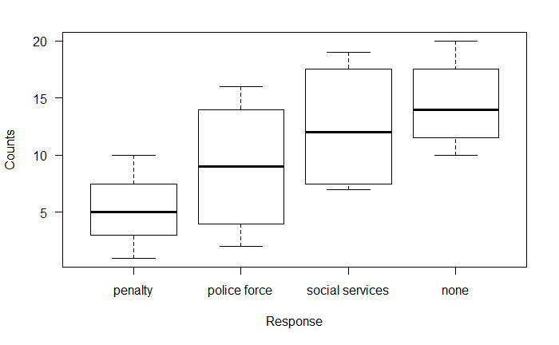

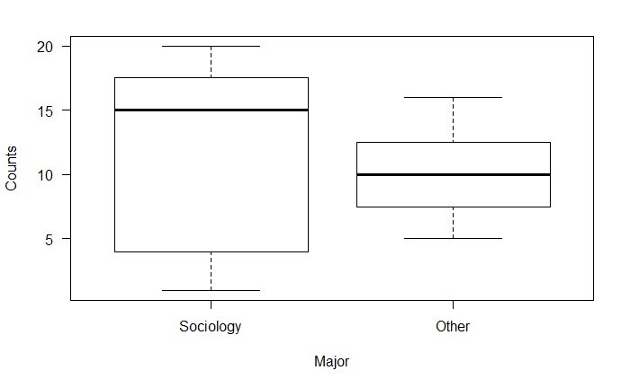

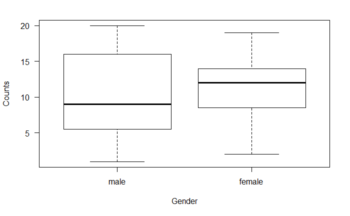

```r
with(ss.counts1,{
  plot( Counts ~ Response, ylab="Counts", las=1)
  plot(Counts ~ Major, ylab="Counts", las=1)
  plot( Counts ~ Gender, ylab="Counts", las=1)
})
```

3. Fit the model.

Let us start with the saturated model.

```r
ss.m1 <- glm(Counts ~  Major * Gender * Response,
             data = ss.counts1,
             family = poisson)
anova(ss.m1, test = "Chisq")
```

[output not shown]

The likelihood test suggests that Major has an interaction with response, but gender does not make a difference.

```r
ss.m2 <- glm(Counts ~ Major * Response,
             data = ss.counts1,
             family = poisson)
anova(ss.m2, test = "Chisq")
```

[output not shown]

The left over (residual) deviance is 5.799 and the associated df is 7. Let’s see if this is substantially different than what we expect for df = 7.

```r
pchisq(5.799, 7, lower.tail = FALSE)
```

```
[1] 0.5634055
```

Overdispersion model is not required.

Here are the coefficients.

```r
printCoefmat(coef(summary(ss.m2)))
```

[output not shown]

The effect sizes.

```r
exp(coef(ss.m2))
```

[output not shown]

The graudate students from other majors have much lower odds to select $social service$ and $none$ than those who from sociology. The odds ratio for selecting social service is 0.06 and the odds ratio for none is 0.09.

4.Diagnostic Analysis

Overdispersion

```r
c(Df = df.residual(ss.m2),
Resid.Dev = deviance(ss.m2),
Pearson.X2 = sum( resid(ss.m2, type="pearson")^2 ))
```

```
        Df  Resid.Dev Pearson.X2
  7.000000   5.798703   5.667495
```

There is not too much difference between the three statistics.

Quantile residual vs fitted values.

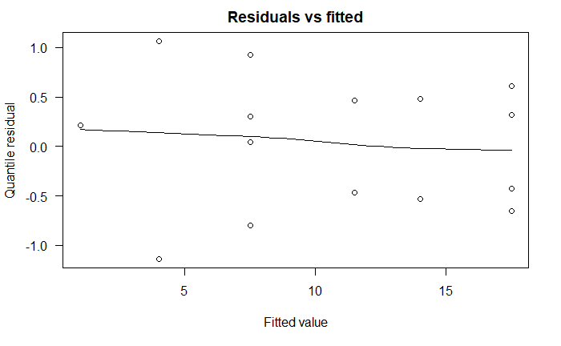

```r
qres <- qresid(ss.m2)
scatter.smooth(qres ~ fitted(ss.m2),
               las = 1,
               main = "Residuals vs fitted",
               xlab = "Fitted value",
               ylab = "Quantile residual")
```

Q-Q Plot

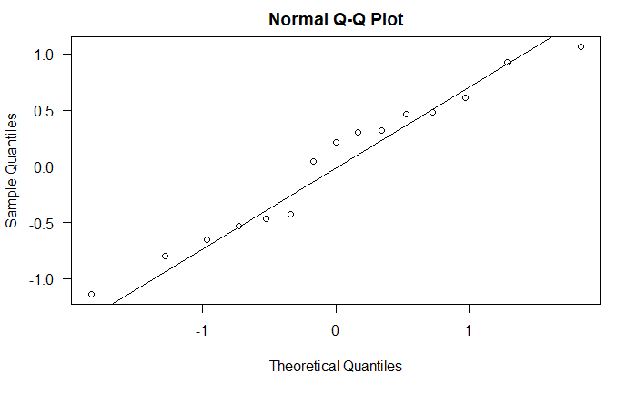

```r
qqnorm(qres, las=1 )
qqline(qres)
```

Cook’s distance

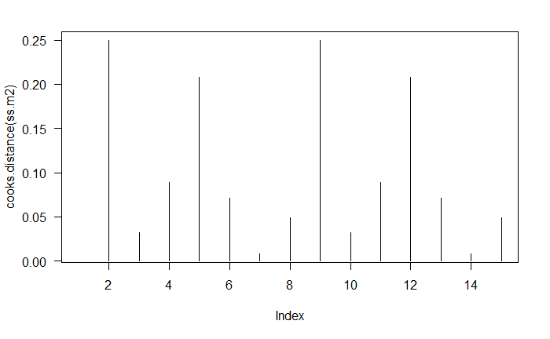

```r
plot( cooks.distance(ss.m2), type="h", las=1)
```

The plots are not bad.

Influential observations

```r
im <- influence.measures(ss.m2)
colSums(im$is.inf)
```

[output not shown]

The influence diagnostics reveal none observations are influential.

#### Additional questions

Is there any evidence of Simpson’s paradox in these data? How do you know?

No, because there is only one interaction in the model and it doesn’t depend on any other factors. ***

### Gamma

The Gamma distribution is used to model positive continuous data.Positive continuous data often have the variance increasing with increasing mean; the inverse Gaussian distribution is used for data more skewed than that suggested by the gamma distribution.

The mean-variance relationship: $V (\mu) = \mu^2$

Dispersion: The dispersion $??$ is unknown and needs to be estimated. MLE estimator cannot be found in closed form. The deviance is sensitive to very small values of $y_i$ for gamma EDMs, the Pearson estimator(R defualt) is recommended.

Link function: 1. inverse link function (canonical and default); 2. log link function; 3. identity link function. In practice, the log link function is more often used to ensure $u>0$ and for interpretaion purposes. Careful choice of the link function and transformations of the covariates can be used to describe asymptotic relationships between $y$ and $x$.

Inference: Wald, score or likelihood ratio test can be used.

The saddlepoint aprroximation is adequate for Gamma distribution when ?? ??? 1/3.

Overdispersion: 1. the $m_i$ cases, of which observation $y_i$ is a proportion, are not independent. (Hierachical models) 2. the Bernoulli cases, that $m_i$ make up observation, are positively correlated. (Quasi-binomial models)

Diagnostic analysis of the model standardized residuals against the fitted values Q-Q plot Cook’s Distance plot Influential observation

#### Data

The data set is available as the *blocks* data in the GLMsData library.

Children were seated at a small table and told to build a tower from the blocks as high as they could. This was demonstrated for the child. The time taken and the number of blocks used were recorded. The cubes were always presented first, then cylinders. The second trial was conducted one month later.

The blocks were half inch cubes and cylinders included in Mrs. Hailmann’s Beads No. 470 of Bradley’s Kindergarten Material. Throughout the article, the children are referred to using male pronouns, but (in keeping with the custom at the time) it is unclear whether all children were males or not. However, since gender is not recorded the children may all have been boys.

The source (Johnson and Courtney, 1931) gives the age in years and months. Here they have been converted to decimal years.

#### Variables

Child: a child identifier from A to Y

Number: the number of blocks the child could successfully stack

Time: the time (in seconds) taken for the child to make the stack of blocks

Trial: the trial number on which the data were gathered

Shape: the shape of the blocks being stacked, either cubes or cylinders

Age: the age of the child (in years)

#### Research questions

*Note: We need our observations to be independent and there were two trials* *in the study, so only use the first trial when analyzing these data.*

Is the shape of the block and age of the child related to the number of blocks that they can put into a tower? Are the effects of age different for the different shapes?

#### Analysis

1.Prepare the data.

```r
data(blocks)
str(blocks)
```

[output not shown]

Subset the data and only select observations of participants’ first trial

```r
block_ft <- subset(blocks, blocks$Trial == 1)
head(block_ft)
```

|  | Child | Number | Time | Trial | Shape | Age |
| --- | --- | --- | --- | --- | --- | --- |
| 1 | A | 11 | 30.0 | 1 | Cube | 4.67 |
| 2 | B | 9 | 19.0 | 1 | Cube | 5.00 |
| 3 | C | 8 | 18.6 | 1 | Cube | 4.42 |
| 4 | D | 9 | 23.0 | 1 | Cube | 4.33 |
| 5 | E | 10 | 29.0 | 1 | Cube | 4.33 |
| 6 | F | 13 | 178.0 | 1 | Cube | 4.83 |

```r
summary(block_ft)
```

[output not shown]

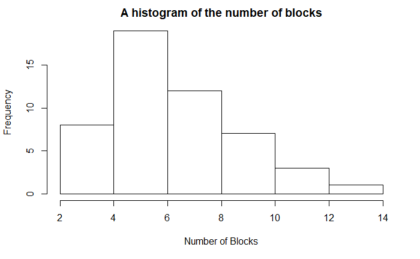

```r
hist(block_ft$Number,
     xlab = "Number of Blocks",
     main = "A histogram of the number of blocks")
```

2. Explore the relationships of each explanatory variable with the response variable.

Let’s start with Shape.

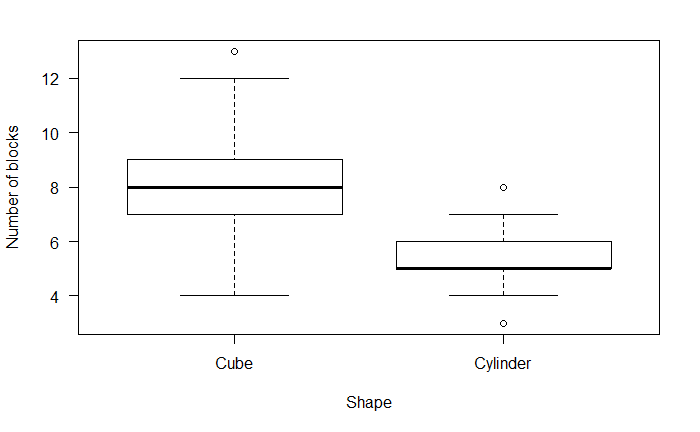

```r
plot(Number ~ Shape,
     data = block_ft,
     las = 1,
     xlab = "Shape",
     ylab = "Number of blocks")
```

Buiding cubical tower on average requires more blocks than cylindrical tower.

Now look at the relationship of number of blocks and age.

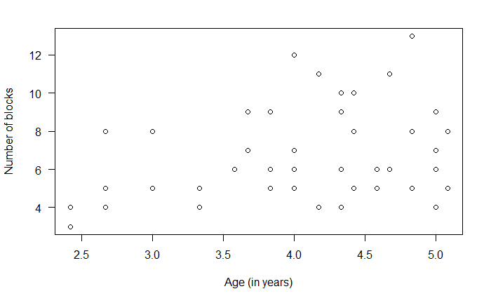

```r
plot(Number ~ Age,
     data = block_ft,
     las = 1,
     xlab = "Age (in years)",
     ylab = "Number of blocks")
```

The number seems to increase as age goes up.

3. Fit the model.

```r
block.log <- glm(Number ~ Shape * Age,
                family = Gamma(link = "identity"),
                data = block_ft)
anova(block.log, test = "F")
```

```
Analysis of Deviance Table

Model: Gamma, link: identity

Response: Number

Terms added sequentially (first to last)

          Df Deviance Resid. Df Resid. Dev       F    Pr(>F)
NULL                         49     5.5821
Shape      1  2.40298        48     3.1791 45.9050 1.981e-08 ***
Age        1  0.54864        47     2.6305 10.4809   0.00224 **
Shape:Age  1  0.21241        46     2.4181  4.0577   0.04984 *
---
Signif. codes:  0 *** 0.001 ** 0.01 * 0.05 . 0.1   1
```

```r
block.log1 <- glm(Number ~ Age * Shape,
                family = Gamma(link = "identity"),
                data = block_ft)
anova(block.log1, test = "F")
```

[output not shown]

We come to the same conclusion.

```r
block.log2 <- glm(Number ~ Shape * Age,
                family = Gamma(link = "identity"),
                data = block_ft)
```

Coefficients and effect sizes

```r
printCoefmat(coef(summary(block.log2)))
```

[output not shown]

4.Diagnostic Analysis

Quantile residual vs fitted values.

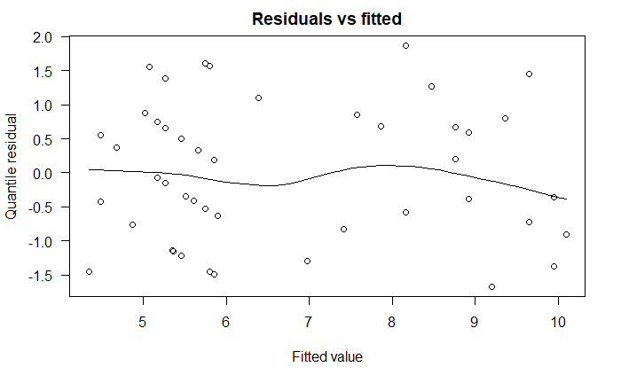

```r
qres <- qresid(block.log2)
scatter.smooth(qres ~ fitted(block.log2),
               las = 1,
               main = "Residuals vs fitted",
               xlab = "Fitted value",
               ylab = "Quantile residual")
```

Q-Q Plot

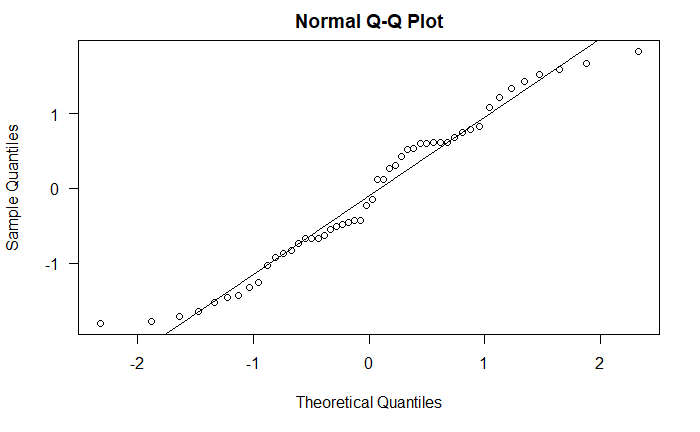

```r
qqnorm(rstandard(block.log2), las=1 )
qqline(rstandard(block.log2))
```

Cook’s distance

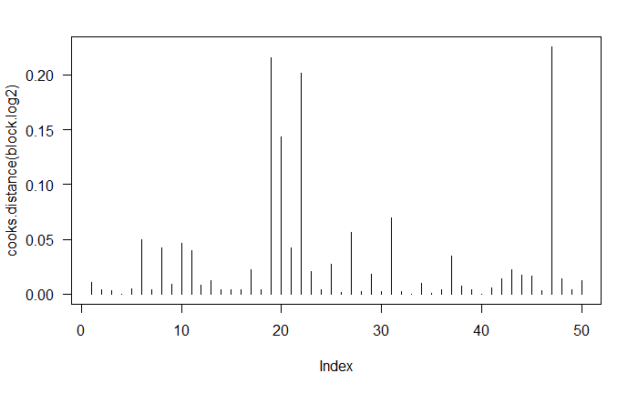

```r
plot( cooks.distance(block.log2), type="h", las=1)
```

The plots are not bad.

Influential observations

```r
im <- influence.measures(block.log2)
colSums(im$is.inf)
```

```
  dfb.1_ dfb.ShpC  dfb.Age dfb.SC:A    dffit    cov.r   cook.d      hat
       0        0        0        0        2        3        0        2
```

No influential observations were detected according to Cook’s distance test.

#### Additional exercise

Group ages into three categories and then use the six groupings (three ages by two blocks shapes) to study the mean-variance relationship. Show that the gamma distribution was a good choice for the random component of the model. (To help with your R code, there is a good example of this process on pages 429 and 430 in the textbook.)

```r
block_ft$AgeGroup <- cut(block_ft$Age, breaks = 3)
vr <- with(block_ft, tapply(Number, list(AgeGroup, Shape), "var"))
mn <- with(block_ft, tapply(Number, list(AgeGroup, Shape), "mean"))
plot( log(vr) ~ log(mn),
      las=1,
      pch=19,
      xlab="log(group means)",
      ylab="log(group variance)")
mf.lm <- lm( c(log(vr)) ~ c(log(mn)) )
coef( mf.lm )
```

```
(Intercept)  c(log(mn))
  -3.248722    2.226512
```

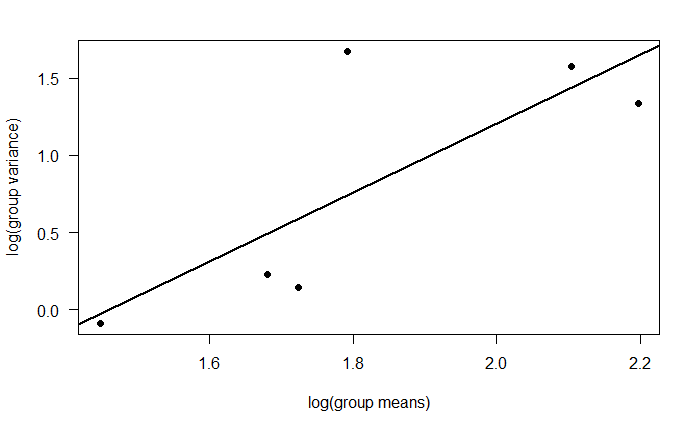

```r
abline( coef( mf.lm ), lwd=2)
```